# classification_crashcourse

### UMAP

Tbh idk much about UMAP even though I use it lol: https://pair-code.github.io/understanding-umap/

##### UMAP Visualization

```python
colors = ['#FF0000', '#FFA500', '#FFFF00', '#008000', '#0000FF', '#800080', '#FF00FF', '#A52A2A', '#008080', '#808080']
def draw_umap(x, y, n_neighbors, min_dist=0.15, metric='euclidean', title=''):
    # mock the user if they didn't infer the constraints
    assert len(n_neighbors) == 4, "Sad tbh"

    # create 2x2 grid
    fig, axs = plt.subplots(2, 2, figsize=(10, 8), subplot_kw={'projection': '3d'})

    # create individual plots
    for ax, neighbor, i in zip(axs.ravel(), n_neighbors, range(4)):
        fit = umap.UMAP(
            n_neighbors=neighbor,
            min_dist=min_dist,
            n_components=N_COMPS,
            metric=metric
        )

        fitter = fit.fit(x, y=y)
        u = fitter.transform(x)

        ax.scatter(u[:,0], u[:,1], u[:,2], c=data_colors)
        ax.set_title(f"neighbors: {neighbor}")
        print(f"Fit umap {i+1} of 4")


    plt.title(title, fontsize=18)
```

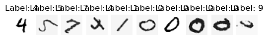

```python
# Prep and augment train data
Xu_train, _, yu_train, _ = train_test_split(mnist["images"], mnist["target"], test_size=0.90, shuffle=True)
n_utrain = Xu_train.shape[0]

# rotate some samples 45
# rot_samples = np.random.choice(n_utrain, size=int(n_utrain/3), replace=False)
# Xu_train[rot_samples] = ndimage.rotate(Xu_train[rot_samples], 45, axes=(1,2), reshape=False)
# # rotate some -45, possibly repeating
# rot_samples = np.random.choice(n_utrain, size=int(n_utrain/3), replace=False)
# Xu_train[rot_samples] = ndimage.rotate(Xu_train[rot_samples], -45, axes=(1,2), reshape=False)

rot_samples = np.random.choice(n_utrain, size=int(n_utrain/2), replace=False)
for samp in rot_samples:
    angle = random.randint(-70, 70)
    try:
        Xu_train[[samp]] = ndimage.rotate(Xu_train[[samp]], angle, axes=(1,2), reshape=False)
    except Exception:
        print(angle)

imgs_to_show = 10
for i in range(imgs_to_show):
    plt.subplot(1, imgs_to_show, i + 1)
    plt.imshow(Xu_train[i], cmap="Greys")
    plt.title("Label: " + str(yu_train[i]))
    plt.axis('off')

# reshape
Xu_train = Xu_train.reshape((Xu_train.shape[0], Xu_train.shape[1] * Xu_train.shape[2]))

# get colors
data_colors = [colors[y] for y in yu_train]
```

```
Fit umap 1 of 4
Fit umap 2 of 4
Fit umap 3 of 4
Fit umap 4 of 4
```

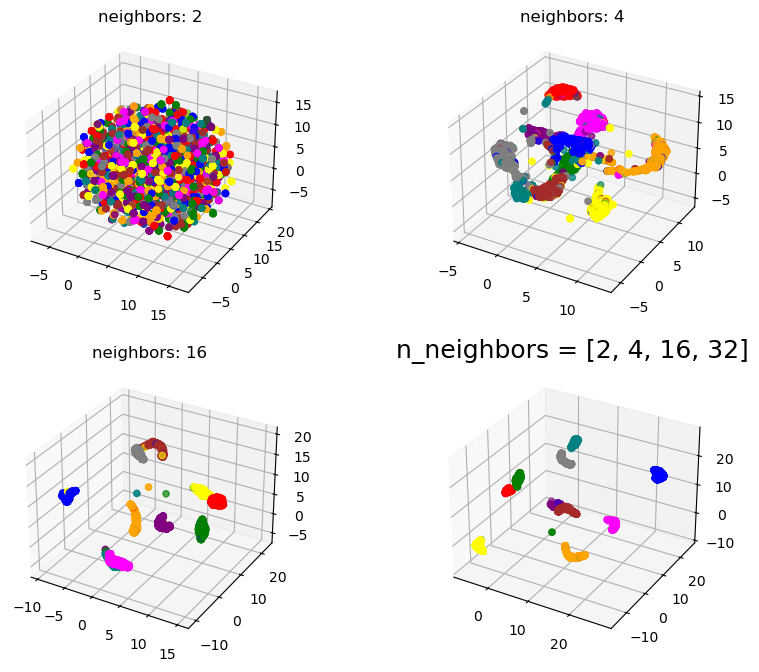

```python
n_ks = [2, 4, 16, 32]
draw_umap(x=Xu_train, y=yu_train, n_neighbors=n_ks, title=f"n_neighbors = {str(n_ks)}")
```

## Create Train/Test Splits and Reduce

```python
def noise(images,prob):
    for i in range(images.shape[0]):
        if random.random() < prob:
            images[i] = random_noise(images[i] / 255, mode="speckle") * 255
            images[i] = random_noise(images[i] / 255, mode="localvar") * 255
            images[i] = np.clip(images[i], 0, 255)
            images[i].astype(int)
```

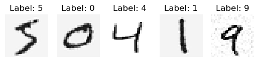

```python
X_train, X_test, y_train, y_test = train_test_split(mnist["images"], mnist["target"], test_size=0.3, shuffle=False)

n_train = X_train.shape[0]

# # rotate some samples 45
# rot_samples = np.random.choice(n_train, size=int(n_train/3), replace=False)
# X_train[rot_samples] = ndimage.rotate(X_train[rot_samples], 45, axes=(1,2), reshape=False)
# # rotate some 180, possibly repeating
# rot_samples = np.random.choice(n_train, size=int(n_train/3), replace=False)
# X_train[rot_samples] = ndimage.rotate(X_train[rot_samples], -45, axes=(1,2), reshape=False)

rot_samples = np.random.choice(n_train, size=int(n_train/2), replace=False)
for samp in rot_samples:
    angle = random.randint(-70, 70)
    try:
        X_train[[samp]] = ndimage.rotate(X_train[[samp]], angle, axes=(1,2), reshape=False)
    except Exception:
        print(angle)

# add noise
noise(X_train, 0.50)

imgs_to_show = 5
for i in range(imgs_to_show):
    plt.subplot(1, imgs_to_show, i + 1)
    plt.imshow(X_train[i], cmap="Greys")
    plt.title("Label: " + str(y_train[i]))
    plt.axis('off')

# reshape
X_train = X_train.reshape((X_train.shape[0], X_train.shape[1] * X_train.shape[2]))
X_test = X_test.reshape((X_test.shape[0], X_test.shape[1] * X_test.shape[2]))
```

```python
###
## UMAP
###
n_comps = 10
n_k = 32
min_dist=0.15
fit = umap.UMAP(
    n_neighbors=n_k,
    min_dist=min_dist,
    n_components=n_comps,
    metric='euclidean'
)
fitter = fit.fit(X_train, y=y_train)
u_train = fitter.transform(X_train)
u_test = fitter.transform(X_test)

###
## PCA
###
n_comps = 10
pca = PCA(n_comps).fit(X_train)
pca_train = pca.transform(X_train)
pca_test = pca.transform(X_test)
```

## Train Classifiers

##### For eval

```python
X_test_imgs = X_test.reshape(X_test.shape[0], 28, 28)
def eval_wrong(model, xa_test, y_test, imgs_to_show = 5):
    y_pred = model.predict(xa_test)
    incorrect_vals = np.where(y_pred != y_test)

    j=0
    for i in incorrect_vals[0]:
        plt.subplot(1, imgs_to_show, j + 1)
        plt.imshow(X_test_imgs[i], cmap="Greys")
        plt.title(f"P: {y_pred[i]}; L: {y_test[i]}")
        plt.axis('off')
        j += 1
        if j >= imgs_to_show:
            break
```

### Neural Networks

A neural network is inspired by how neurons firing in the brain leads to decision making in biological systems. It takes in data usually related to some labeled output we wish to predict and attempts to pick up on the complicated patterns within them. The simplest neural network consists of an input layer, a hidden layer, and an output layer. Based on the values of the data coming in, certain nodes of the hidden layers “light up” (have a higher value) depending on whether the value of the node exceeds some value, it then fires the number to the next connecting node (or to an output if it’s a single layer). For classification, your output is usually some "probability" related to which output it considers most likely.

### NN w/ UMAP

```python
nn_u = MLPClassifier(
        verbose = True,
        activation='relu',
        learning_rate='adaptive',
        tol=1e-5,
        alpha=0.001,
        hidden_layer_sizes=(10, 10),
        solver="adam",
)

nn_u.fit(u_train, y_train)
```

```
Iteration 1, loss = 2.76637129
Iteration 2, loss = 1.29031395
Iteration 3, loss = 0.50603140
Iteration 4, loss = 0.07101034
Iteration 5, loss = 0.03847482
Iteration 6, loss = 0.03121913
Iteration 7, loss = 0.02949435
Iteration 8, loss = 0.02878296
Iteration 9, loss = 0.02823124
Iteration 10, loss = 0.02789106
Iteration 11, loss = 0.02745017
Iteration 12, loss = 0.02712073
Iteration 13, loss = 0.02674608
Iteration 14, loss = 0.02628047
Iteration 15, loss = 0.02573326
Iteration 16, loss = 0.02545707
Iteration 17, loss = 0.02499394
Iteration 18, loss = 0.02460361
Iteration 19, loss = 0.02422905
Iteration 20, loss = 0.02396816
Iteration 21, loss = 0.02366097
Iteration 22, loss = 0.02342949
Iteration 23, loss = 0.02318699
Iteration 24, loss = 0.02310184
Iteration 25, loss = 0.02304403
Iteration 26, loss = 0.02276352
Iteration 27, loss = 0.02262399
Iteration 28, loss = 0.02256995
Iteration 29, loss = 0.02238120
Iteration 30, loss = 0.02227457
Iteration 31, loss = 0.02213102
Iteration 32, loss = 0.02209564
Iteration 33, loss = 0.02196529
Iteration 34, loss = 0.02184917
Iteration 35, loss = 0.02167973
Iteration 36, loss = 0.02158467
Iteration 37, loss = 0.02170221
Iteration 38, loss = 0.02143014
Iteration 39, loss = 0.02133577
Iteration 40, loss = 0.02128559
```

[output cut: 63 more lines]

```
Iteration 104, loss = 0.01887274
Iteration 105, loss = 0.01876698
Iteration 106, loss = 0.01851916
Iteration 107, loss = 0.01872451
Iteration 108, loss = 0.01874469
Iteration 109, loss = 0.01869024
Iteration 110, loss = 0.01874283
Iteration 111, loss = 0.01864298
Iteration 112, loss = 0.01869161
Iteration 113, loss = 0.01873817
Iteration 114, loss = 0.01868119
Iteration 115, loss = 0.01867437
Iteration 116, loss = 0.01867158
Iteration 117, loss = 0.01876211
Training loss did not improve more than tol=0.000010 for 10 consecutive epochs. Stopping.
```

```
MLPClassifier(alpha=0.001, hidden_layer_sizes=(10, 10),
              learning_rate='adaptive', tol=1e-05, verbose=True)
```

```python
nn_y_pred = nn_u.predict(u_test)
print(f"Macro F1: {metrics.f1_score(y_test, nn_y_pred, average='macro')}")
print(f"Micro F1: {metrics.f1_score(y_test, nn_y_pred, average='micro')}")
print(f"Accuracy: {metrics.accuracy_score(y_test, nn_y_pred)}")
print(f"Precision: {metrics.precision_score(y_test, nn_y_pred, average='micro')}")
```

```
Macro F1: 0.9446412686953023
Micro F1: 0.9444761904761905
Accuracy: 0.9444761904761905
Precision: 0.9444761904761905
```

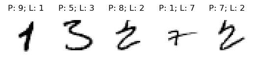

```python
eval_wrong(nn_u, u_test, y_test, imgs_to_show = 5)
```

##### NN w/ PCA

```python
nn_pca = MLPClassifier(
        verbose = True,
        activation='relu',
        learning_rate='adaptive',
        tol=1e-5,
        alpha=0.001,
        hidden_layer_sizes=(128, 128, 24),
        solver="adam",
)

nn_pca.fit(pca_train, y_train)
```

```
Iteration 1, loss = 2.87913392
Iteration 2, loss = 1.35828347
Iteration 3, loss = 1.13427732
Iteration 4, loss = 0.98538169
Iteration 5, loss = 0.86503386
Iteration 6, loss = 0.76004505
Iteration 7, loss = 0.68516908
Iteration 8, loss = 0.63736105
Iteration 9, loss = 0.59861151
Iteration 10, loss = 0.56652015
Iteration 11, loss = 0.54545761
Iteration 12, loss = 0.51841887
Iteration 13, loss = 0.49934582
Iteration 14, loss = 0.48926320
Iteration 15, loss = 0.47301335
Iteration 16, loss = 0.45656778
Iteration 17, loss = 0.44512329
Iteration 18, loss = 0.43517382
Iteration 19, loss = 0.41871093
Iteration 20, loss = 0.41003580
Iteration 21, loss = 0.40009097
Iteration 22, loss = 0.39300580
Iteration 23, loss = 0.38230049
Iteration 24, loss = 0.37466980
Iteration 25, loss = 0.36907597
Iteration 26, loss = 0.36425606
Iteration 27, loss = 0.35689742
Iteration 28, loss = 0.35177341
Iteration 29, loss = 0.34916200
Iteration 30, loss = 0.34629038
Iteration 31, loss = 0.34226647
Iteration 32, loss = 0.33734294
Iteration 33, loss = 0.33329554
Iteration 34, loss = 0.33037187
Iteration 35, loss = 0.32653900
Iteration 36, loss = 0.32196494
Iteration 37, loss = 0.32053318
Iteration 38, loss = 0.31740564
Iteration 39, loss = 0.31254884
Iteration 40, loss = 0.31496595
```

[output cut: 145 more lines]

```
Iteration 186, loss = 0.15383400
Iteration 187, loss = 0.15737642
Iteration 188, loss = 0.15219451
Iteration 189, loss = 0.15284928
Iteration 190, loss = 0.15759642
Iteration 191, loss = 0.15031998
Iteration 192, loss = 0.15574123
Iteration 193, loss = 0.14713316
Iteration 194, loss = 0.14995377
Iteration 195, loss = 0.15069008
Iteration 196, loss = 0.15666652
Iteration 197, loss = 0.14947475
Iteration 198, loss = 0.14907860
Iteration 199, loss = 0.14873921
Iteration 200, loss = 0.14697762
```

```
MLPClassifier(alpha=0.001, hidden_layer_sizes=(128, 128, 24),
              learning_rate='adaptive', tol=1e-05, verbose=True)
```

```python
nn_y_pred = nn_pca.predict(pca_test)
print(f"Macro F1: {metrics.f1_score(y_test, nn_y_pred, average='macro')}")
print(f"Micro F1: {metrics.f1_score(y_test, nn_y_pred, average='micro')}")
print(f"Accuracy: {metrics.accuracy_score(y_test, nn_y_pred)}")
print(f"Precision: {metrics.precision_score(y_test, nn_y_pred, average='micro')}")
```

```
Macro F1: 0.9013072730024418
Micro F1: 0.9022380952380953
Accuracy: 0.9022380952380953
Precision: 0.9022380952380953
```

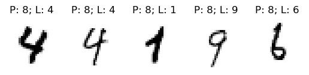

```python
eval_wrong(nn_pca, u_test, y_test, imgs_to_show = 5)
```

### Random Forest

Random Forests is an ensembled learning technique which constructs many decision trees, often limited to only some of the features, and allows them to "vote" on the best solution. Additionally, these trees often use bootstrapped samples (a sampled subset with replacement). If bootstrapping is used, one can use out-of-bag samples (which is, the data not used from sampling) for evaluation of the model, without needing to utilize the test/validation set.

Decision trees work by selecting the best splitting feature and value (node) based on a metric (e.g. Gini impurity, entropy). These splits continue until some stopping criterion is met, e.g. all values in the split belong to one class, maximum tree depth is reached, number of samples exceeds minimum number of samples for split.

[ESLII for more info](https://hastie.su.domains/Papers/ESLII.pdf)

```python
rf_u = RandomForestClassifier(
    verbose = True,
    n_estimators=300,
    min_samples_split=4,
    max_features="sqrt",
)
rf_u.fit(u_train, y_train)
```

```
[Parallel(n_jobs=1)]: Done  49 tasks      | elapsed:    7.2s
[Parallel(n_jobs=1)]: Done 199 tasks      | elapsed:   29.7s
```

```
RandomForestClassifier(min_samples_split=4, n_estimators=300, verbose=True)
```

```python
rf_y_pred = rf_u.predict(u_test)
print(f"Macro F1: {metrics.f1_score(y_test, rf_y_pred, average='macro')}")
print(f"Micro F1: {metrics.f1_score(y_test, rf_y_pred, average='micro')}")
print(f"Accuracy: {metrics.accuracy_score(y_test, rf_y_pred)}")
print(f"Precision: {metrics.precision_score(y_test, rf_y_pred, average='micro')}")
```

```
[Parallel(n_jobs=1)]: Done  49 tasks      | elapsed:    0.0s
[Parallel(n_jobs=1)]: Done 199 tasks      | elapsed:    0.3s
```

```
Macro F1: 0.9446932414533264
Micro F1: 0.9445238095238095
Accuracy: 0.9445238095238095
Precision: 0.9445238095238095
```

```
[Parallel(n_jobs=1)]: Done  49 tasks      | elapsed:    0.0s
[Parallel(n_jobs=1)]: Done 199 tasks      | elapsed:    0.3s
```

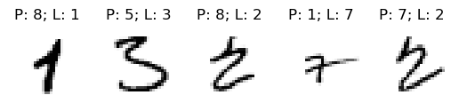

```python
eval_wrong(rf_u, u_test, y_test, imgs_to_show = 5)
```

### Gradient Boosted Machine

Gradient Boosted Machines (GBMs) are another ensembled learning approach that utilizes decision trees (usually) sequentially. That is, each new tree learns and corrects the errors of the prior. To do this, GBMs use gradient descent optimization. Each interaction `n_classes` trees are fit on the negative gradient of the loss function. That is, the model is fit to the residuals (or *pseudo* residuals) rather than the values. Because of this, the final prediction, rather than being a weighted vote like the Random Forest, is a weighted sum of the predictions, where the weight is determined in the training process.

[ESLII for more info](https://hastie.su.domains/Papers/ESLII.pdf)

```python
gbm_u = GradientBoostingClassifier(
               verbose = True,
               n_estimators=300,
               min_samples_split=4,
               tol=1e-5,
               max_features="sqrt",
)
gbm_u.fit(u_train, y_train)
```

```
      Iter       Train Loss   Remaining Time
         1           1.4632            3.82m
         2           1.1154            3.81m
         3           0.8836            3.80m
         4           0.7136            3.80m
         5           0.5836            3.80m
         6           0.4820            3.78m
         7           0.3989            3.77m
         8           0.3318            3.75m
         9           0.2767            3.74m
        10           0.2314            3.73m
        20           0.0464            3.60m
        30           0.0152            3.47m
        40           0.0076            3.34m
        50           0.0039            3.21m
        60           0.0024            3.08m
        70           0.0016            2.95m
        80           0.0012            2.82m
        90           0.0009            2.69m
       100           0.0006            2.57m
       200           0.0001            1.28m
       300           0.0000            0.00s
```

```
GradientBoostingClassifier(max_features='sqrt', min_samples_split=4,
                           n_estimators=300, tol=1e-05, verbose=True)
```

```python
gbm_y_pred = gbm_u.predict(u_test)
print(f"Macro F1: {metrics.f1_score(y_test, gbm_y_pred, average='macro')}")
print(f"Micro F1: {metrics.f1_score(y_test, gbm_y_pred, average='micro')}")
print(f"Accuracy: {metrics.accuracy_score(y_test, gbm_y_pred)}")
print(f"Precision: {metrics.precision_score(y_test, gbm_y_pred, average='micro')}")
```

```
Macro F1: 0.9416442566217142
Micro F1: 0.9415714285714286
Accuracy: 0.9415714285714286
Precision: 0.9415714285714286
```

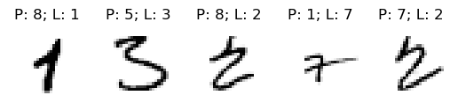

```python
eval_wrong(gbm_u, u_test, y_test, imgs_to_show = 5)
```